[figure not shown]

# Session 4 Exercise: Differential Accessibility and Visualization

Author

Rockefeller University, Bioinformatics Resource Centre

Published

Invalid Date

These exercises are about differential accessibility testing and coverage plots in [Single-cell ATAC-seq](https://rockefelleruniversity.github.io/scATAC/).

We continue with the E18 mouse brain object from the Session 3 exercise. In the session we found markers for a cell type in blood. Here we look for the regulatory elements that separate **progenitors** from **neurons** in the developing cortex.

If you don’t have the object from the Session 3 exercise, download ours into your **data/** folder. It points to the fragment file at `data/atac_v1_E18_brain_flash_5k_fragments.tsv.gz`, so you also need the fragment file and its index there (see the Session 2 exercise).

```r
options(timeout = 600)
download.file(
  url      = "https://www.dropbox.com/scl/fi/87aj4rcvif8imjhm3dx9x/brain_annotated.rds?rlkey=wkprulmx6wyx6c1qhbfdfqawz&st=eladqt36&dl=1",
  destfile = "data/brain_annotated.rds",
  mode     = "wb"
)
```

**Exercise 1** - **Choosing groups to compare**

- Load your annotated object from the Session 3 exercise. Set the default assay to peaks and use your clusters as the identities.

[output not shown]

[output not shown]

[output not shown]

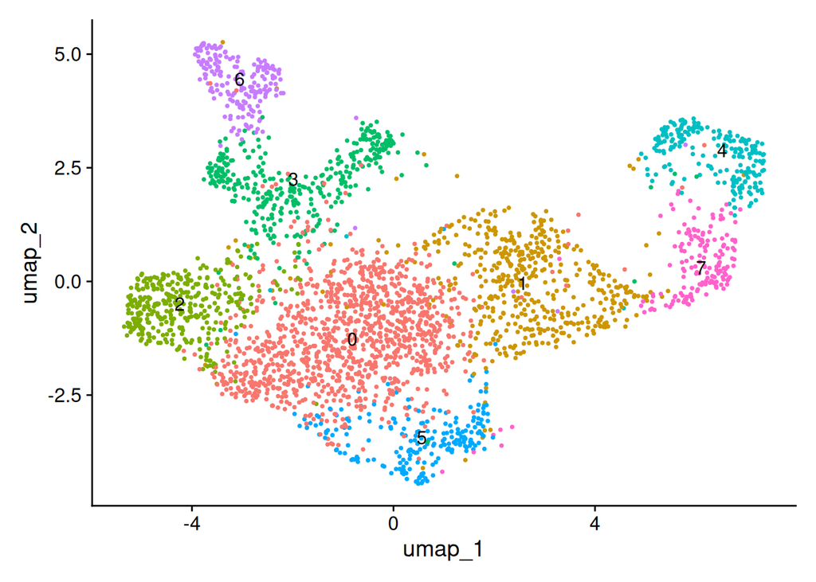

- Use the gene activity assay to find the cluster with the highest *Pax6* activity (radial glia) and the cluster with the highest *Neurod6* activity (excitatory neurons). Don’t just read it off a plot. Compute the average per cluster.

```
As of Seurat v5, we recommend using AggregateExpression to perform pseudo-bulk analysis.
First group.by variable `peaks_snn_res.0.8` starts with a number, appending `g` to ensure valid variable names
```

```
5 x 8 sparse Matrix of class "dgCMatrix"
          g0   g1   g2   g3   g4   g5   g6   g7
Pax6    1.34 0.81 2.09 0.72 0.31 1.10 0.51 0.48
Sox2    0.35 0.16 0.61 0.32 0.11 0.22 0.37 0.05
Eomes   0.30 0.14 0.29 0.19 0.09 0.21 0.17 0.08
Neurod6 0.34 0.43 0.08 0.06 0.54 0.44 0.05 0.37
Neurod2 0.32 0.63 0.09 0.15 1.01 0.57 0.30 0.56
```

```
progenitor     neuron
       "2"        "4"
```

- What did label transfer from the adult Allen reference call the cells in these two clusters? Does that fit what you expected?

```
     Astro       Endo    L2/3 IT         L4      L5 IT      L5 PT      L6 CT
        65          4          7         11         22          2          4
     L6 IT      Lamp5 Macrophage         NP      Oligo       Peri      Pvalb
        52         39          1          3         16          5         48
  Serpinf1        Sst        Vip
         1         33         57
```

```
L2/3 IT      L4   L5 IT   L5 PT   L6 CT   L6 IT     L6b   Lamp5      NP   Pvalb
     20      14      21       3      48      46      21      21       2       3
    Sst     Vip
      9      16
```

**Exercise 2** - **Differential accessibility**

- Find peaks more accessible in the progenitor cluster than in all other cells. Use logistic regression with sequencing depth as a latent variable, as in the session. Why do we include depth?

```
                                p_val avg_log2FC pct.1 pct.2    p_val_adj
chr18-42644462-42645178  5.007620e-83   4.801482 0.297 0.012 2.690845e-78
chr5-33703848-33706154   1.468459e-81   3.727996 0.368 0.033 7.890763e-77
chr7-79194514-79195430   2.400522e-73   3.680547 0.338 0.029 1.289920e-68
chr11-8863898-8864663    3.821202e-73   4.670253 0.284 0.011 2.053323e-68
chr7-117462189-117462910 2.310732e-66   4.602746 0.259 0.011 1.241672e-61
chr6-85320269-85320919   5.497007e-66   4.377974 0.262 0.013 2.953817e-61
```

```
[1] 2577
```

- Now compare the progenitor cluster directly against the neuron cluster, keeping both directions. How many peaks are significantly more open in each? What does a negative avg_log2FC mean here?

```
direction
    neuron progenitor
      2814       2366
```

- Make a volcano plot of the pairwise result.

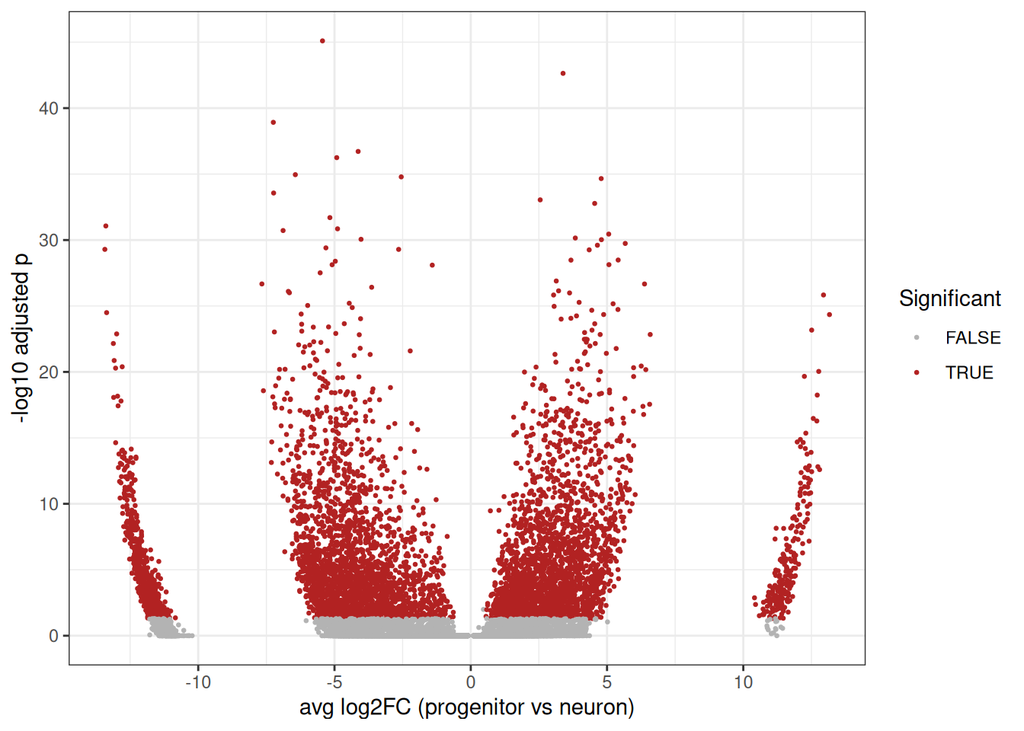

- Your volcano plot probably has two separate “wings” of points at very large fold changes (around ±12). What are these peaks? Should you rank peaks by fold change?

```
                         avg_log2FC pct.1 pct.2
chr13-29550070-29550910   -13.39068 0.000 0.424
chr10-92615643-92616441   -13.42653 0.000 0.415
chr2-147298047-147298911   12.94281 0.257 0.000
chr11-63758709-63759887   -13.36161 0.000 0.375
chr2-148889852-148890629   13.16224 0.284 0.000
chr14-75472890-75474108    12.50878 0.238 0.000
```

**Exercise 3** - **What genes are nearby?**

- Annotate the significant pairwise peaks with their closest gene. Look at the most significant ones in each direction. Do you recognise any genes from the developing cortex?

```
                          avg_log2FC    p_val_adj gene_name distance
chr2-26499875-26504382      3.386273 2.311821e-43    Notch1        0
chr1-119328646-119330208    4.785991 2.196984e-35     Inhbb    85256
chr5-140606277-140612776    2.547652 9.025256e-34      Lfng        0
chr5-112132658-112134639    4.546511 1.679774e-33    Cryba4   111853
chr7-79194514-79195430      5.061912 3.548906e-31     Mfge8    45453
chr8-25274443-25276713      3.835426 7.043642e-31     Tacc1    17854
chr3-85299694-85300680      4.794152 9.411360e-31   Gm37240        0
chr18-5159591-5161011       5.668372 1.821485e-30      Svil    40291
chr1-119255047-119257260    4.646725 2.487127e-30     Inhbb   158204
chr14-76254549-76255706     4.345613 5.560975e-30    Nufip1   117169
chr13-84448610-84449911     5.408158 3.286907e-29  Tmem161b   152468
chr14-118229890-118232272   3.676342 3.343600e-29     Sox21      959
chr5-33703848-33706154      5.069988 7.381580e-29     Fgfr3    15519
chr11-77892793-77895035     3.137208 1.275660e-27     Pipox        0
chr16-29882565-29884033     6.375523 2.150287e-27      Hes1   180350
```

```
                          avg_log2FC    p_val_adj gene_name distance
chr4-103576145-103578468   -5.440913 7.964774e-46      Dab1    40890
chr10-116402636-116404289  -7.244820 1.195775e-39     Ptprb    13100
chr10-84357326-84359372    -4.132546 1.925640e-37     Nuak1    11532
chr14-102918872-102920210  -4.917961 5.678311e-37    Kctd12    56370
chr12-26546256-26547814    -6.437056 1.110337e-35     Cmpk2    66418
chr14-64584881-64599935    -2.551235 1.633245e-35    Kif13b    47329
chr13-93091747-93092574    -7.233904 2.732304e-34     Cmya5        0
chr14-102902291-102903590  -5.169228 1.999985e-32    Kctd12    72990
chr13-29550070-29550910   -13.390679 8.581644e-32    Cdkal1        0
chr14-12377255-12379413    -4.888231 1.414860e-31     Cadps        0
chr15-67494658-67495575    -6.886483 1.912550e-31   St3gal1   317827
chr7-112241175-112242876   -4.026389 8.823717e-31    Mical2        0
chr8-104126915-104127997   -5.315263 3.937887e-30      Cdh5        0
chr10-92615643-92616441   -13.426528 5.108297e-30     Nedd1    68304
chr11-98316975-98331114    -2.646516 5.132421e-30   Neurod2        0
```

- Check whether known progenitor and neuron genes appear among the nearest genes, and on which side.

```
                          gene_name avg_log2FC    p_val_adj distance
chr12-108049563-108050158    Bcl11b  -4.409509 2.408008e-08    45960
chr12-107392346-107392780    Bcl11b  -4.287989 4.190907e-03   517622
chr12-107920726-107921498    Bcl11b  -4.246402 1.826899e-02        0
chr10-57783297-57785197       Fabp7   2.843087 1.681376e-14        0
chr16-29882565-29884033        Hes1   6.375523 2.150287e-27   180350
chr16-30062803-30065560        Hes1   2.616881 9.800159e-20        0
chr16-29893743-29894872        Hes1   3.652284 1.979283e-15   169511
chr16-30022494-30023620        Hes1   2.198698 1.638333e-05    40763
chr16-30069808-30070874        Hes1   1.903378 4.022196e-04     2011
chr16-30059256-30059775        Hes1   4.328350 2.128930e-02     4608
chr4-154948255-154949767       Hes5   3.519164 1.070445e-13    11155
chr4-154957324-154958965       Hes5   1.856101 6.081877e-06     1957
chr13-83132617-83133683       Mef2c  -7.664404 2.135486e-27   370350
chr13-83884759-83885961       Mef2c   5.136257 3.203014e-11   217678
chr13-83376113-83376543       Mef2c  -5.794877 1.667043e-07   127490
chr13-83480469-83481899       Mef2c  -3.476003 1.009727e-02    22134
chr11-98316975-98331114     Neurod2  -2.646516 5.132421e-30        0
chr6-55680602-55683914      Neurod6  -3.363363 1.484277e-15        0
chr2-26499875-26504382       Notch1   3.386273 2.311821e-43        0
chr2-26485159-26488068       Notch1   3.058957 1.069982e-25        0
chr2-26475405-26475895       Notch1   4.021469 3.139281e-07        0
chr2-105672359-105676855       Pax6   2.768052 1.191230e-17        0
chr2-105680143-105683337       Pax6   2.385470 6.862305e-09        0
chr2-105668495-105669909       Pax6   4.987088 4.412055e-07        0
chr2-105686475-105688818       Pax6   1.979448 2.121386e-05        0
chr2-105659633-105661590       Pax6   1.877078 4.705005e-03     7309
chr1-56738517-56739275        Satb2 -11.382573 4.663263e-05    54705
chr3-34659038-34665548         Sox2   2.237855 1.789782e-16     6576
chr3-34647672-34651491         Sox2   2.045237 2.344174e-15        0
chr3-35084172-35084800         Sox2   5.139450 2.558946e-10   431710
chr3-35088183-35089153         Sox2   2.676357 1.350433e-08   435721
chr3-34642075-34643947         Sox2   1.890983 4.680808e-08     6457
chr3-35090460-35090900         Sox2   3.170666 9.772967e-06   437998
chr3-34443776-34444443         Sox2   2.804721 1.230453e-02   205961
chr2-61802614-61807660         Tbr1  -2.167863 8.109749e-17        0
chr2-13573080-13576521          Vim   1.063689 3.004606e-04        0
```

- What fraction of significant peaks are more than 10 kb from their closest gene? What kind of elements are these likely to be, and why is “nearest gene” a weak assumption for them?

```
[1] 0.3666023
```

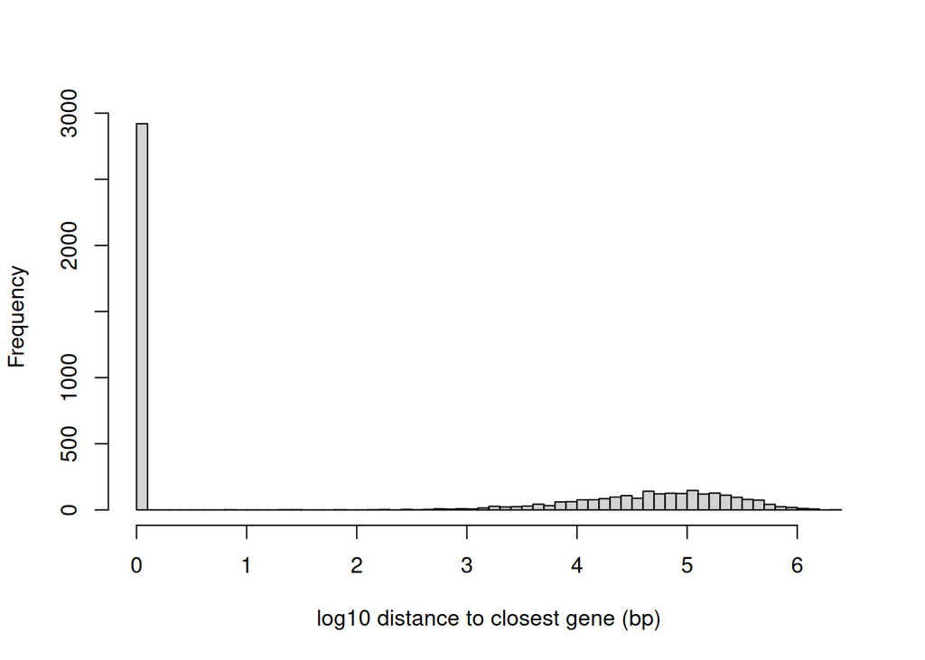

**Exercise 4** - **Coverage plots**

- Draw a coverage plot at *Pax6* and at *Neurod6* for all clusters, with gene activity shown alongside. Do the tracks agree with your choice of clusters?

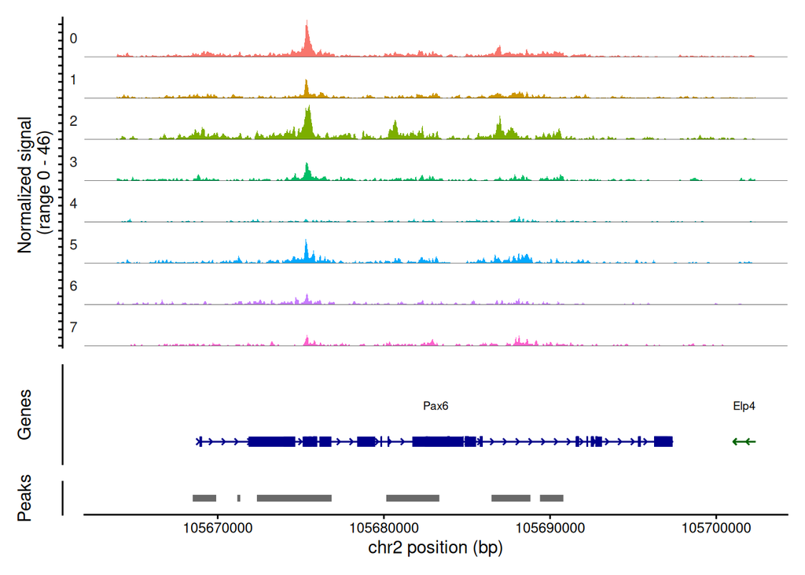

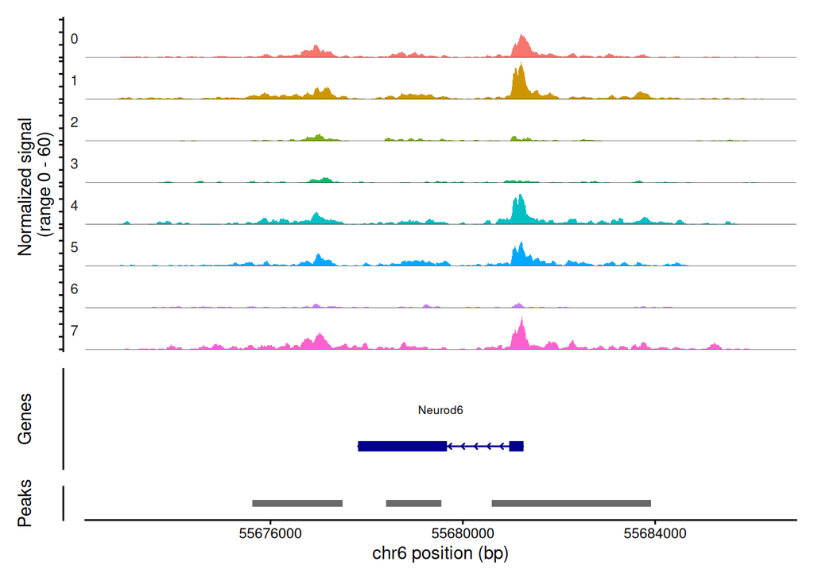

- In the session the panel next to the coverage plot was labelled as expression. What is it actually showing for us, and why does that matter?
- Plot the most significant progenitor-specific and neuron-specific peaks from your pairwise test, showing only the two clusters you compared.

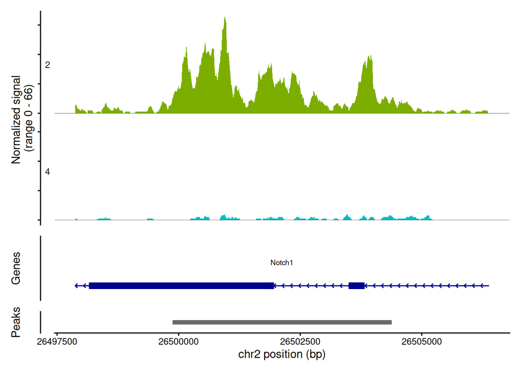

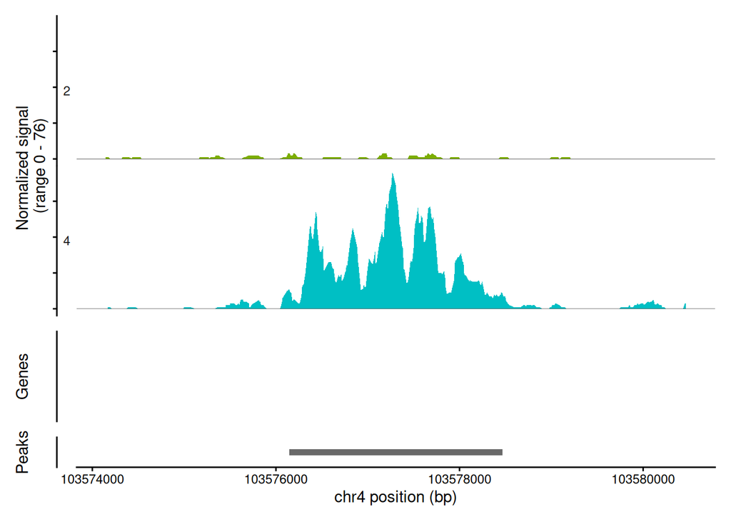

**Exercise 5** - **Markers as QC**

- Look at the one-vs-rest progenitor markers with a critical eye. Are any on chrX, chrY or chrM? Are any driven by very few cells (low pct.1)? What would each of these tell you?

```
 chr1 chr10 chr11 chr12 chr13 chr14 chr15 chr16 chr17 chr18 chr19  chr2  chr3
  163   113   166   108    86   113   104   104    91    86    57   259   143
 chr4  chr5  chr6  chr7  chr8  chr9  chrX
  204   155   148   152   156   140    29
```

```
   Min. 1st Qu.  Median    Mean 3rd Qu.    Max.
  0.051   0.092   0.132   0.155   0.195   0.716
```

- Is the progenitor cluster unusual for any QC metric? Could any of its markers be explained by quality instead of biology?

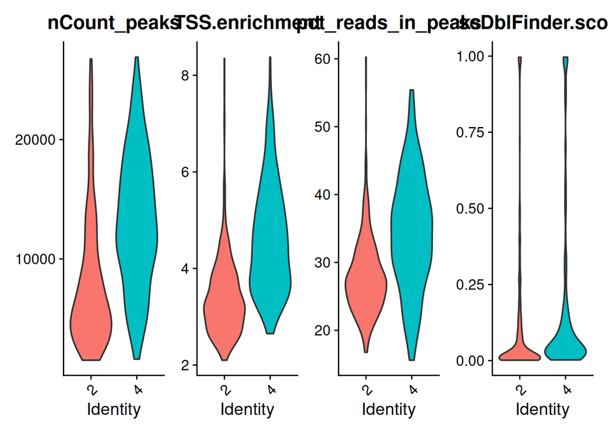

- In the session we ran `FindAllMarkers()` on 500 cells and it took ~40 minutes. This dataset has ~8x more cells. What could you change to make it practical? (No need to run it.)